# Problem Set 7: Image Recognition

Zach Grande & Janvi Wadhawan  
3/16/2022  
INFO 371

```python
import numpy as np
import pandas as pd
import tensorflow as tf
tf.get_logger().setLevel('ERROR')
print("tensorflow version", tf.__version__)
from tensorflow.keras.preprocessing.image import ImageDataGenerator, load_img
from tensorflow.keras.utils import to_categorical
from sklearn.model_selection import train_test_split
import matplotlib.pyplot as plt
import os
import sys
```

```
tensorflow version 2.8.0
```

# 1. Introduction

**1.1** Write a neural network model that runs on the image data and outputs confusion matrix and accuracy. Let us not bother with good accuracy here, just get it to run. Feel free to adapt the the squares-circles, or cats-dogs example code (note: the latter uses multicolor images!).

This problem set uses a neural network structure adopted from `cats-n-dogs.py`. The introductory model uses images from all four languages. Images are forced to a shape of 200x500 with one color channel.

This model runs very quickly as two epochs do not train the model very thoroughly. To simplify discussion surrounding the exact layers of the neural network, we will discuss complexity in terms of the number of parameters used in the model. Here, `78,468` parameters are included.

The model has 0.4431 accuracy. Clearly speed is favored over accuracy as two epochs with few parameters allow it to run in less than a minute. We can see that the model is prone to classifying EN images as ZN images, which is confusing since the characters in their respective languages look very different.

| predicted | DA | EN | RU | ZN |
| --- | --- | --- | --- | --- |
| DA | 202 | 286 | 50 | 475 |
| EN | 3 | 130 | 47 | 1858 |
| RU | 8 | 118 | 1052 | 524 |
| ZN | 0 | 27 | 2 | 1320 |

`Accuracy 0.4431`

```python
## Define image properties:
imgDir = "../../data/language"
targetWidth, targetHeight = 200, 500
imageSize = (targetWidth, targetHeight)
channels = 1  # color channels
```

```python
## define other constants, including command line argument defaults
batch_size = 16
epochs = 2
```

This code block had originally chosen 1,000 file names for early testing. After this was verified to work, the line of code was commented out.

```python
## Prepare dataset for training model:
original_filenames = os.listdir(os.path.join(imgDir, "train"))

# pick 1,000 random images from total directory for early testing
import random
# original_filenames = random.sample(original_filenames, 1000)

filenames = []
categories = []

for x in original_filenames:
  language = x.split("_")[1:][0]
  filenames.append(x)
  categories.append(language[:2])

print(len(filenames), "images found")
df = pd.DataFrame({
    'filename':filenames,
    'category':pd.Series(categories)
})
print("data files:")
print(df.sample(5))
nCategories = df.category.nunique()
print("categories:\n", df.category.value_counts())
## Create model
from tensorflow.keras.models import Sequential
from tensorflow.keras.layers import Conv2D,\
    MaxPooling2D, AveragePooling2D,\
    Dropout,Flatten,Dense,Activation,\
    BatchNormalization
```

```
24410 images found
data files:
                               filename category
20854  tolstoy-voina-i-mir-1_RU-avi.jpg       RU
9062         ling-chu-ko-pai_ZN-bhw.jpg       ZN
13700                dracula_EN-dji.jpg       EN
1087   tolstoy-voina-i-mir-3_RU-blm.jpg       RU
15564           chinese-laws_ZN-cpc.jpg       ZN
categories:
 EN    8454
RU    6502
ZN    5353
DA    4101
Name: category, dtype: int64
```

```python
# sequential (not recursive) model (one input, one output)
model=Sequential()

model.add(Conv2D(16,
                 kernel_size=3,
                 strides=2,
                 activation='relu',
                 input_shape=(targetWidth, targetHeight, channels)))
model.add(BatchNormalization())
model.add(MaxPooling2D(pool_size=3))
model.add(Dropout(0.25))

model.add(Conv2D(8,
                 kernel_size=3,
                 activation='relu'))
model.add(BatchNormalization())
model.add(MaxPooling2D(pool_size=(2, 2)))
model.add(Dropout(0.25))

model.add(Flatten())
model.add(Dense(16, activation='relu'))
model.add(BatchNormalization())
model.add(Dropout(0.5))
model.add(Dense(8, activation='softmax'))

model.add(Dense(nCategories, activation='softmax'))

model.compile(loss='categorical_crossentropy',
              metrics=['accuracy'])
model.summary()
```

```
Model: "sequential_3"
_________________________________________________________________
 Layer (type)                Output Shape              Param #
=================================================================
 conv2d_6 (Conv2D)           (None, 99, 249, 16)       160

 batch_normalization_9 (Batc  (None, 99, 249, 16)      64
 hNormalization)

 max_pooling2d_6 (MaxPooling  (None, 33, 83, 16)       0
 2D)

 dropout_9 (Dropout)         (None, 33, 83, 16)        0

 conv2d_7 (Conv2D)           (None, 31, 81, 8)         1160

 batch_normalization_10 (Bat  (None, 31, 81, 8)        32
 chNormalization)

 max_pooling2d_7 (MaxPooling  (None, 15, 40, 8)        0
 2D)

 dropout_10 (Dropout)        (None, 15, 40, 8)         0

 flatten_3 (Flatten)         (None, 4800)              0

 dense_9 (Dense)             (None, 16)                76816

 batch_normalization_11 (Bat  (None, 16)               64
 chNormalization)

 dropout_11 (Dropout)        (None, 16)                0

 dense_10 (Dense)            (None, 8)                 136

 dense_11 (Dense)            (None, 4)                 36

=================================================================
Total params: 78,468
Trainable params: 78,388
Non-trainable params: 80
_________________________________________________________________
```

```python
## Training and validation data generator:
train_generator = ImageDataGenerator(rescale=1./255).\
    flow_from_dataframe(df,
                        os.path.join(imgDir, "train"),
                        x_col='filename', y_col='category',
                        target_size=imageSize,
                        class_mode='categorical',
                        color_mode="grayscale",
                        batch_size=batch_size,
                        shuffle=True)
label_map = train_generator.class_indices
## Model Training:
history = model.fit(
    train_generator,
    epochs=epochs
)
```

```
Found 24410 validated image filenames belonging to 4 classes.
```

```python
## Test data preparation:
testDir = os.path.join(imgDir, "test")
fNames = os.listdir(testDir)

filenames = []
categories = []

for x in fNames:
  language = x.split("_")[1:][0]
  filenames.append(x)
  categories.append(language[:2])

print(len(filenames), "test images")
testResults = pd.DataFrame({
    'filename': filenames,
    'category': categories
})
nb_samples = testResults.shape[0]
print(nb_samples, "test files read from", testDir)
test_generator = ImageDataGenerator(rescale=1./255).\
    flow_from_dataframe(testResults,
                        os.path.join(imgDir, "test"),
                        x_col='filename',
                        class_mode = None,
                        target_size = imageSize,
                        batch_size=batch_size,
                        shuffle = False,
                        # do _not_ randomize the order!
                        # this would clash with the file name order!
                        color_mode="grayscale"
    )
```

```
6102 test images
6102 test files read from ../../data/language/test
Found 6102 validated image filenames.
```

**1.2** At the end of your code, add predictions on validation data, print the confusion matrix, and compute the final testing accuracy. This is the final performance measure of your model.

```python
## Make categorical prediction:
print("predicting")
phat = model.predict(test_generator)
print("Predicted array shape:", phat.shape)
print("Example:\n", phat[:5])
```

```
predicting
Predicted array shape: (6102, 4)
Example:
 [[0.01012501 0.01057617 0.01688666 0.9624122 ]
 [0.08176515 0.89693713 0.01764167 0.00365601]
 [0.01013611 0.01058843 0.01691243 0.96236306]
 [0.01012582 0.0105762  0.01688679 0.9624112 ]
 [0.01794724 0.01874773 0.03398651 0.92931855]]
```

```python
## Convert labels to categories:
testResults['predicted'] = pd.Series(np.argmax(phat, axis=-1), index=testResults.index)
print(testResults.head())
labelMap = {v: k for k, v in label_map.items()}
testResults["predicted"] = testResults.predicted.replace(labelMap)
print("confusion matrix")
print(pd.crosstab(testResults.category, testResults.predicted))
print("Accuracy", np.mean(testResults.category == testResults.predicted))
```

```
                            filename category  predicted
0            chinese-laws_ZN-frt.jpg       ZN          3
1  derzhavin-duhovnye-ody_RU-aty.jpg       RU          1
2            chinese-laws_ZN-djp.jpg       ZN          3
3            chinese-laws_ZN-avm.jpg       ZN          3
4                 dracula_EN-doy.jpg       EN          3
confusion matrix
predicted   DA   EN    RU    ZN
category
DA         202  286    50   475
EN           3  130    47  1858
RU           8  118  1052   524
ZN           0   27     2  1320
Accuracy 0.44313339888561126
```

# 2. EN vs. ZN

## Attempt 1: 78k Parameters, 1 Epoch

This is the first attempt to distinguish EN from ZN. A `for` loop is implemented to extract the language classification of each file and subsequently filter out DA and RU. This model is similar to the last one in that the neural network uses a similar structure with `78,336` parameters. However, one epoch is used so we can quickly test the model.

As a test, the dimensions in the second to last dense layer was reduced to `2`. This slightly reduced the number of parameters. The model produced `0.9988` accuracy despite this change as it distinguished EN from ZN. With only four mislabeled images, this is extremely good.

The ending chunks of this model plot the four images mislabeled by the model. One image contains no characters, and the other is ZN **but** it contains mostly EN characters. If the data was cleaned before use to exclude these two outliers, the model would have `0.9994` accuracy under similar conditions.

| predicted | EN | ZN |
| --- | --- | --- |
| EN | 2038 | 0 |
| ZN | 4 | 1345 |

`Accuracy 0.9988`

```python
## Define image properties:
imgDir = "../../data/language"
targetWidth, targetHeight = 200, 500
imageSize = (targetWidth, targetHeight)
channels = 1  # color channels
```

```python
## define other constants, including command line argument defaults
batch_size = 16
epochs = 1
```

```python
## Prepare dataset for training model:
original_filenames = os.listdir(os.path.join(imgDir, "train"))

filenames = []
categories = []

for x in original_filenames:
  language = x.split("_")[1:][0]
  if "EN-" in language or "ZN-" in language:
    filenames.append(x)
    categories.append(language[:2])

print(len(filenames), "images found")
df = pd.DataFrame({
    'filename':filenames,
    'category':pd.Series(categories)
})

print("data files:")
print(df.sample(5))
nCategories = df.category.nunique()
print("categories:\n", df.category.value_counts())
## Create model
from tensorflow.keras.models import Sequential
from tensorflow.keras.layers import Conv2D,\
    MaxPooling2D, AveragePooling2D,\
    Dropout,Flatten,Dense,Activation,\
    BatchNormalization
```

```
13807 images found
data files:
                      filename category
6559   ocean-tramps_EN-baq.jpg       EN
6778   ocean-tramps_EN-afw.jpg       EN
10199  chinese-laws_ZN-fnc.jpg       ZN
3224   liu-shouyuan_ZN-alj.jpg       ZN
268         journey_EN-aor.jpg       EN
categories:
 EN    8454
ZN    5353
Name: category, dtype: int64
```

```python
# sequential (not recursive) model (one input, one output)
model=Sequential()

model.add(Conv2D(16,
                 kernel_size=3,
                 strides=2,
                 activation='relu',
                 input_shape=(targetWidth, targetHeight, channels)))
model.add(BatchNormalization())
model.add(MaxPooling2D(pool_size=3))
model.add(Dropout(0.25))

model.add(Conv2D(8,
                 kernel_size=3,
                 activation='relu'))
model.add(BatchNormalization())
model.add(MaxPooling2D(pool_size=(2, 2)))
model.add(Dropout(0.25))

model.add(Flatten())
model.add(Dense(16, activation='relu'))
model.add(BatchNormalization())
model.add(Dropout(0.5))
model.add(Dense(2, activation='softmax'))

model.add(Dense(nCategories, activation='softmax'))

model.compile(loss='categorical_crossentropy',
              metrics=['accuracy'])
model.summary()
```

```
Model: "sequential_15"
_________________________________________________________________
 Layer (type)                Output Shape              Param #
=================================================================
 conv2d_30 (Conv2D)          (None, 99, 249, 16)       160

 batch_normalization_45 (Bat  (None, 99, 249, 16)      64
 chNormalization)

 max_pooling2d_30 (MaxPoolin  (None, 33, 83, 16)       0
 g2D)

 dropout_45 (Dropout)        (None, 33, 83, 16)        0

 conv2d_31 (Conv2D)          (None, 31, 81, 8)         1160

 batch_normalization_46 (Bat  (None, 31, 81, 8)        32
 chNormalization)

 max_pooling2d_31 (MaxPoolin  (None, 15, 40, 8)        0
 g2D)

 dropout_46 (Dropout)        (None, 15, 40, 8)         0

 flatten_15 (Flatten)        (None, 4800)              0

 dense_45 (Dense)            (None, 16)                76816

 batch_normalization_47 (Bat  (None, 16)               64
 chNormalization)

 dropout_47 (Dropout)        (None, 16)                0

 dense_46 (Dense)            (None, 2)                 34

 dense_47 (Dense)            (None, 2)                 6

=================================================================
Total params: 78,336
Trainable params: 78,256
Non-trainable params: 80
_________________________________________________________________
```

```python
## Training and validation data generator:
train_generator = ImageDataGenerator(rescale=1./255).\
    flow_from_dataframe(df,
                        os.path.join(imgDir, "train"),
                        x_col='filename', y_col='category',
                        target_size=imageSize,
                        class_mode='categorical',
                        color_mode="grayscale",
                        batch_size=batch_size,
                        shuffle=True)
label_map = train_generator.class_indices
## Model Training:
history = model.fit(
    train_generator,
    epochs=epochs
)
```

```
Found 13807 validated image filenames belonging to 2 classes.
```

```python
## Test data preparation:
testDir = os.path.join(imgDir, "test")
fNames = os.listdir(testDir)

filenames = []
categories = []

for x in fNames:
  language = x.split("_")[1:][0]
  if "EN-" in language or "ZN-" in language:
    filenames.append(x)
    categories.append(language[:2])


print(len(filenames), "test images")
testResults = pd.DataFrame({
    'filename': filenames,
    'category': pd.Series(categories)
})
nb_samples = testResults.shape[0]
print(nb_samples, "test files read from", testDir)
test_generator = ImageDataGenerator(rescale=1./255).\
    flow_from_dataframe(testResults,
                        os.path.join(imgDir, "test"),
                        x_col='filename',
                        class_mode = None,
                        target_size = imageSize,
                        batch_size=batch_size,
                        shuffle = False,
                        # do _not_ randomize the order!
                        # this would clash with the file name order!
                        color_mode="grayscale"
    )
```

```
3387 test images
3387 test files read from ../../data/language/test
Found 3387 validated image filenames.
```

```python
## Make categorical prediction:
print("predicting")
phat = model.predict(test_generator)
print("Predicted array shape:", phat.shape)
print("Example:\n", phat[:5])
```

```
predicting
Predicted array shape: (3387, 2)
Example:
 [[0.13543208 0.86456794]
 [0.13543203 0.86456794]
 [0.13543203 0.86456794]
 [0.9235772  0.07642276]
 [0.13543203 0.86456794]]
```

```python
## Convert labels to categories:
testResults['predicted'] = pd.Series(np.argmax(phat, axis=-1), index=testResults.index)
print(testResults.head())
labelMap = {v: k for k, v in label_map.items()}
testResults["predicted"] = testResults.predicted.replace(labelMap)
print("confusion matrix")
print(pd.crosstab(testResults.category, testResults.predicted))
print("Accuracy", np.mean(testResults.category == testResults.predicted))
```

```
                  filename category  predicted
0  chinese-laws_ZN-frt.jpg       ZN          1
1  chinese-laws_ZN-djp.jpg       ZN          1
2  chinese-laws_ZN-avm.jpg       ZN          1
3       dracula_EN-doy.jpg       EN          0
4  chinese-laws_ZN-auv.jpg       ZN          1
confusion matrix
predicted    EN    ZN
category
EN         2038     0
ZN            4  1345
Accuracy 0.998819013876587
```

```
Example wrong results
                                 filename category predicted
634               chinese-laws_ZN-axa.jpg       ZN        EN
217  lin-huang-tien-fei-hsieng_ZN-aab.jpg       ZN        EN
598               liu-shouyuan_ZN-anv.jpg       ZN        EN
106               liu-shouyuan_ZN-aul.jpg       ZN        EN
```

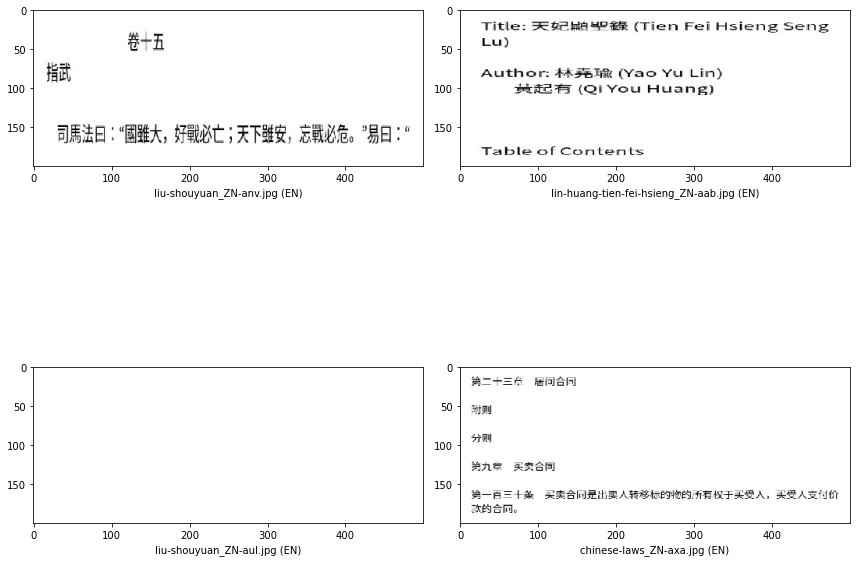

```python
## Print and plot misclassified results
wrongResults = testResults[testResults.predicted != testResults.category]
rows = np.random.choice(wrongResults.index, min(4, wrongResults.shape[0]), replace=False)
print("Example wrong results")
print(wrongResults.sample(min(10, wrongResults.shape[0])))
plt.figure(figsize=(12, 12))
index = 1
for row in rows:
    filename = wrongResults.loc[row, 'filename']
    predicted = wrongResults.loc[row, 'predicted']
    img = load_img(os.path.join(imgDir, "test", filename), target_size=imageSize)
    plt.subplot(2, 2, index)
    plt.imshow(img)
    plt.xlabel(filename + " ({})".format(predicted))
    index += 1
plt.tight_layout()
plt.show()
```

## Attempt 2: 20M parameters, 5 Epochs

This model is an attempt to perfectly distinguish EN/ZN at the cost of a long runtime. This model uses 20 million parameters, runs for 5 epochs, and takes just over 25 minutes to run.

| predicted | EN | ZN |
| --- | --- | --- |
| EN | 2038 | 0 |
| ZN | 2 | 1347 |

`Accuracy 0.9994`

```python
## Define image properties:
imgDir = "../../data/language"
targetWidth, targetHeight = 200, 500
imageSize = (targetWidth, targetHeight)
channels = 1  # color channels
```

```python
## define other constants, including command line argument defaults
batch_size = 16
epochs = 5
```

```python
## Prepare dataset for training model:
original_filenames = os.listdir(os.path.join(imgDir, "train"))

filenames = []
categories = []

for x in original_filenames:
  language = x.split("_")[1:][0]
  if "EN-" in language or "ZN-" in language:
    filenames.append(x)
    categories.append(language[:2])

print(len(filenames), "images found")
df = pd.DataFrame({
    'filename':filenames,
    'category':pd.Series(categories)
})

print("data files:")
print(df.sample(5))
nCategories = df.category.nunique()
print("categories:\n", df.category.value_counts())
## Create model
from tensorflow.keras.models import Sequential
from tensorflow.keras.layers import Conv2D,\
    MaxPooling2D, AveragePooling2D,\
    Dropout,Flatten,Dense,Activation,\
    BatchNormalization
```

```
13807 images found
data files:
                               filename category
9468                 dracula_EN-cor.jpg       EN
10205              evolution_EN-bub.jpg       EN
3458            chinese-laws_ZN-ftw.jpg       ZN
10021  tommy-rem-battle-book_EN-air.jpg       EN
10523           chinese-laws_ZN-ffo.jpg       ZN
categories:
 EN    8454
ZN    5353
Name: category, dtype: int64
```

```python
# sequential (not recursive) model (one input, one output)
model=Sequential()

model.add(Conv2D(32, # 16
                 kernel_size=3,
                 strides=2,
                 activation='relu',
                 input_shape=(targetWidth, targetHeight, channels)))
model.add(BatchNormalization())
model.add(MaxPooling2D(pool_size=3))
model.add(Dropout(0.25))

model.add(Conv2D(64, # 8
                 kernel_size=3,
                 activation='relu'))
model.add(BatchNormalization())
model.add(MaxPooling2D(pool_size=(2, 2)))
model.add(Dropout(0.25))

model.add(Flatten())
model.add(Dense(512, activation='relu'))  # 16
model.add(BatchNormalization())
model.add(Dropout(0.5))
model.add(Dense(2, activation='softmax'))

model.add(Dense(nCategories, activation='softmax'))

model.compile(loss='categorical_crossentropy',
              metrics=['accuracy'])
model.summary()
```

```
Model: "sequential_13"
_________________________________________________________________
 Layer (type)                Output Shape              Param #
=================================================================
 conv2d_26 (Conv2D)          (None, 99, 249, 32)       320

 batch_normalization_39 (Bat  (None, 99, 249, 32)      128
 chNormalization)

 max_pooling2d_26 (MaxPoolin  (None, 33, 83, 32)       0
 g2D)

 dropout_39 (Dropout)        (None, 33, 83, 32)        0

 conv2d_27 (Conv2D)          (None, 31, 81, 64)        18496

 batch_normalization_40 (Bat  (None, 31, 81, 64)       256
 chNormalization)

 max_pooling2d_27 (MaxPoolin  (None, 15, 40, 64)       0
 g2D)

 dropout_40 (Dropout)        (None, 15, 40, 64)        0

 flatten_13 (Flatten)        (None, 38400)             0

 dense_39 (Dense)            (None, 512)               19661312

 batch_normalization_41 (Bat  (None, 512)              2048
 chNormalization)

 dropout_41 (Dropout)        (None, 512)               0

 dense_40 (Dense)            (None, 2)                 1026

 dense_41 (Dense)            (None, 2)                 6

=================================================================
Total params: 19,683,592
Trainable params: 19,682,376
Non-trainable params: 1,216
_________________________________________________________________
```

```python
## Training and validation data generator:
train_generator = ImageDataGenerator(rescale=1./255).\
    flow_from_dataframe(df,
                        os.path.join(imgDir, "train"),
                        x_col='filename', y_col='category',
                        target_size=imageSize,
                        class_mode='categorical',
                        color_mode="grayscale",
                        batch_size=batch_size,
                        shuffle=True)
label_map = train_generator.class_indices
## Model Training:
history = model.fit(
    train_generator,
    epochs=epochs
)
```

```
Found 13807 validated image filenames belonging to 2 classes.
```

```python
## Test data preparation:
testDir = os.path.join(imgDir, "test")
fNames = os.listdir(testDir)

filenames = []
categories = []

for x in fNames:
  language = x.split("_")[1:][0]
  if "EN-" in language or "ZN-" in language:
    filenames.append(x)
    categories.append(language[:2])


print(len(filenames), "test images")
testResults = pd.DataFrame({
    'filename': filenames,
    'category': pd.Series(categories)
})
nb_samples = testResults.shape[0]
print(nb_samples, "test files read from", testDir)
test_generator = ImageDataGenerator(rescale=1./255).\
    flow_from_dataframe(testResults,
                        os.path.join(imgDir, "test"),
                        x_col='filename',
                        class_mode = None,
                        target_size = imageSize,
                        batch_size=batch_size,
                        shuffle = False,
                        # do _not_ randomize the order!
                        # this would clash with the file name order!
                        color_mode="grayscale"
    )
```

```
3387 test images
3387 test files read from ../../data/language/test
Found 3387 validated image filenames.
```

```python
## Make categorical prediction:
print("predicting")
phat = model.predict(test_generator)
print("Predicted array shape:", phat.shape)
print("Example:\n", phat[:5])
```

```
predicting
Predicted array shape: (3387, 2)
Example:
 [[3.6979653e-04 9.9963021e-01]
 [3.6979653e-04 9.9963021e-01]
 [3.6979653e-04 9.9963021e-01]
 [9.9976116e-01 2.3888062e-04]
 [3.6979653e-04 9.9963021e-01]]
```

```python
## Convert labels to categories:
testResults['predicted'] = pd.Series(np.argmax(phat, axis=-1), index=testResults.index)
print(testResults.head())
labelMap = {v: k for k, v in label_map.items()}
testResults["predicted"] = testResults.predicted.replace(labelMap)
print("confusion matrix")
print(pd.crosstab(testResults.category, testResults.predicted))
print("Accuracy", np.mean(testResults.category == testResults.predicted))
```

```
                  filename category  predicted
0  chinese-laws_ZN-frt.jpg       ZN          1
1  chinese-laws_ZN-djp.jpg       ZN          1
2  chinese-laws_ZN-avm.jpg       ZN          1
3       dracula_EN-doy.jpg       EN          0
4  chinese-laws_ZN-auv.jpg       ZN          1
confusion matrix
predicted    EN    ZN
category
EN         2038     0
ZN            2  1347
Accuracy 0.9994095069382934
```

```
Example wrong results
                    filename category predicted
382  chinese-laws_ZN-dqx.jpg       ZN        EN
106  liu-shouyuan_ZN-aul.jpg       ZN        EN
```

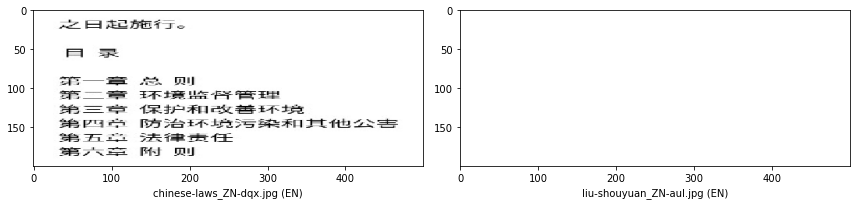

```python
## Print and plot misclassified results
wrongResults = testResults[testResults.predicted != testResults.category]
rows = np.random.choice(wrongResults.index, min(4, wrongResults.shape[0]), replace=False)
print("Example wrong results")
print(wrongResults.sample(min(10, wrongResults.shape[0])))
plt.figure(figsize=(12, 12))
index = 1
for row in rows:
    filename = wrongResults.loc[row, 'filename']
    predicted = wrongResults.loc[row, 'predicted']
    img = load_img(os.path.join(imgDir, "test", filename), target_size=imageSize)
    plt.subplot(2, 2, index)
    plt.imshow(img)
    plt.xlabel(filename + " ({})".format(predicted))
    index += 1
plt.tight_layout()
plt.show()
```

## Attempt 3: 78,336 Parameters, 10 Epochs

This model has the same parameters as Attempt 1, but was modified to run for 10 epochs. The runtime here is over 15 minutes, which is appropriate for 200x500 pixels.

The confusion matrix of this model shows that it may have been a victim of overfitting. This model produces the worst results, despite running 9 more times than Attempt 1. While 0.98 accuracy is an acceptable rate, we know we can achieve a faster runtime and better results with the first model.

| predicted | EN | ZN |
| --- | --- | --- |
| EN | 2038 | 0 |
| ZN | 63 | 1286 |

`Accuracy 0.9814`

```python
## Define image properties:
imgDir = "../../data/language"
targetWidth, targetHeight = 200, 500
imageSize = (targetWidth, targetHeight)
channels = 1  # color channels
```

```python
## define other constants, including command line argument defaults
batch_size = 16
epochs = 10
```

```python
## Prepare dataset for training model:
original_filenames = os.listdir(os.path.join(imgDir, "train"))

filenames = []
categories = []

for x in original_filenames:
  language = x.split("_")[1:][0]
  if "EN-" in language or "ZN-" in language:
    filenames.append(x)
    categories.append(language[:2])

print(len(filenames), "images found")
df = pd.DataFrame({
    'filename':filenames,
    'category':pd.Series(categories)
})

print("data files:")
print(df.sample(5))
nCategories = df.category.nunique()
print("categories:\n", df.category.value_counts())
## Create model
from tensorflow.keras.models import Sequential
from tensorflow.keras.layers import Conv2D,\
    MaxPooling2D, AveragePooling2D,\
    Dropout,Flatten,Dense,Activation,\
    BatchNormalization
```

```
13807 images found
data files:
                         filename category
1296      chinese-laws_ZN-gxb.jpg       ZN
1526      ocean-tramps_EN-cck.jpg       EN
1997   ling-chu-ko-pai_ZN-adq.jpg       ZN
12810        evolution_EN-eci.jpg       EN
1915      ocean-tramps_EN-cco.jpg       EN
categories:
 EN    8454
ZN    5353
Name: category, dtype: int64
```

```python
# sequential (not recursive) model (one input, one output)
model=Sequential()

model.add(Conv2D(16,
                 kernel_size=3,
                 strides=2,
                 activation='relu',
                 input_shape=(targetWidth, targetHeight, channels)))
model.add(BatchNormalization())
model.add(MaxPooling2D(pool_size=3))
model.add(Dropout(0.25))

model.add(Conv2D(8,
                 kernel_size=3,
                 activation='relu'))
model.add(BatchNormalization())
model.add(MaxPooling2D(pool_size=(2, 2)))
model.add(Dropout(0.25))

model.add(Flatten())
model.add(Dense(16, activation='relu'))
model.add(BatchNormalization())
model.add(Dropout(0.5))
model.add(Dense(2, activation='softmax'))

model.add(Dense(nCategories, activation='softmax'))

model.compile(loss='categorical_crossentropy',
              metrics=['accuracy'])
model.summary()
```

```
Model: "sequential_14"
_________________________________________________________________
 Layer (type)                Output Shape              Param #
=================================================================
 conv2d_28 (Conv2D)          (None, 99, 249, 16)       160

 batch_normalization_42 (Bat  (None, 99, 249, 16)      64
 chNormalization)

 max_pooling2d_28 (MaxPoolin  (None, 33, 83, 16)       0
 g2D)

 dropout_42 (Dropout)        (None, 33, 83, 16)        0

 conv2d_29 (Conv2D)          (None, 31, 81, 8)         1160

 batch_normalization_43 (Bat  (None, 31, 81, 8)        32
 chNormalization)

 max_pooling2d_29 (MaxPoolin  (None, 15, 40, 8)        0
 g2D)

 dropout_43 (Dropout)        (None, 15, 40, 8)         0

 flatten_14 (Flatten)        (None, 4800)              0

 dense_42 (Dense)            (None, 16)                76816

 batch_normalization_44 (Bat  (None, 16)               64
 chNormalization)

 dropout_44 (Dropout)        (None, 16)                0

 dense_43 (Dense)            (None, 2)                 34

 dense_44 (Dense)            (None, 2)                 6

=================================================================
Total params: 78,336
Trainable params: 78,256
Non-trainable params: 80
_________________________________________________________________
```

```python
## Training and validation data generator:
train_generator = ImageDataGenerator(rescale=1./255).\
    flow_from_dataframe(df,
                        os.path.join(imgDir, "train"),
                        x_col='filename', y_col='category',
                        target_size=imageSize,
                        class_mode='categorical',
                        color_mode="grayscale",
                        batch_size=batch_size,
                        shuffle=True)
label_map = train_generator.class_indices
## Model Training:
history = model.fit(
    train_generator,
    epochs=epochs
)
```

```
Found 13807 validated image filenames belonging to 2 classes.
```

```python
## Test data preparation:
testDir = os.path.join(imgDir, "test")
fNames = os.listdir(testDir)

filenames = []
categories = []

for x in fNames:
  language = x.split("_")[1:][0]
  if "EN-" in language or "ZN-" in language:
    filenames.append(x)
    categories.append(language[:2])


print(len(filenames), "test images")
testResults = pd.DataFrame({
    'filename': filenames,
    'category': pd.Series(categories)
})
nb_samples = testResults.shape[0]
print(nb_samples, "test files read from", testDir)
test_generator = ImageDataGenerator(rescale=1./255).\
    flow_from_dataframe(testResults,
                        os.path.join(imgDir, "test"),
                        x_col='filename',
                        class_mode = None,
                        target_size = imageSize,
                        batch_size=batch_size,
                        shuffle = False,
                        # do _not_ randomize the order!
                        # this would clash with the file name order!
                        color_mode="grayscale"
    )
```

```
3387 test images
3387 test files read from ../../data/language/test
Found 3387 validated image filenames.
```

```python
## Make categorical prediction:
print("predicting")
phat = model.predict(test_generator)
print("Predicted array shape:", phat.shape)
print("Example:\n", phat[:5])
```

```
predicting
Predicted array shape: (3387, 2)
Example:
 [[6.1329330e-05 9.9993873e-01]
 [6.1289866e-05 9.9993873e-01]
 [6.1290040e-05 9.9993873e-01]
 [9.9996066e-01 3.9323269e-05]
 [6.1294253e-05 9.9993873e-01]]
```

```python
## Convert labels to categories:
testResults['predicted'] = pd.Series(np.argmax(phat, axis=-1), index=testResults.index)
print(testResults.head())
labelMap = {v: k for k, v in label_map.items()}
testResults["predicted"] = testResults.predicted.replace(labelMap)
print("confusion matrix")
print(pd.crosstab(testResults.category, testResults.predicted))
print("Accuracy", np.mean(testResults.category == testResults.predicted))
```

```
                  filename category  predicted
0  chinese-laws_ZN-frt.jpg       ZN          1
1  chinese-laws_ZN-djp.jpg       ZN          1
2  chinese-laws_ZN-avm.jpg       ZN          1
3       dracula_EN-doy.jpg       EN          0
4  chinese-laws_ZN-auv.jpg       ZN          1
confusion matrix
predicted    EN    ZN
category
EN         2038     0
ZN           63  1286
Accuracy 0.9813994685562445
```

```
Example wrong results
                                  filename category predicted
182                chinese-laws_ZN-cwj.jpg       ZN        EN
634                chinese-laws_ZN-axa.jpg       ZN        EN
103             bai-li-wa-zhuan_ZN-aam.jpg       ZN        EN
562                chinese-laws_ZN-elw.jpg       ZN        EN
382                chinese-laws_ZN-dqx.jpg       ZN        EN
1433               chinese-laws_ZN-fom.jpg       ZN        EN
2302               chinese-laws_ZN-ckh.jpg       ZN        EN
1046               chinese-laws_ZN-fxb.jpg       ZN        EN
648   lin-huang-tien-fei-hsieng_ZN-abh.jpg       ZN        EN
598                liu-shouyuan_ZN-anv.jpg       ZN        EN
```

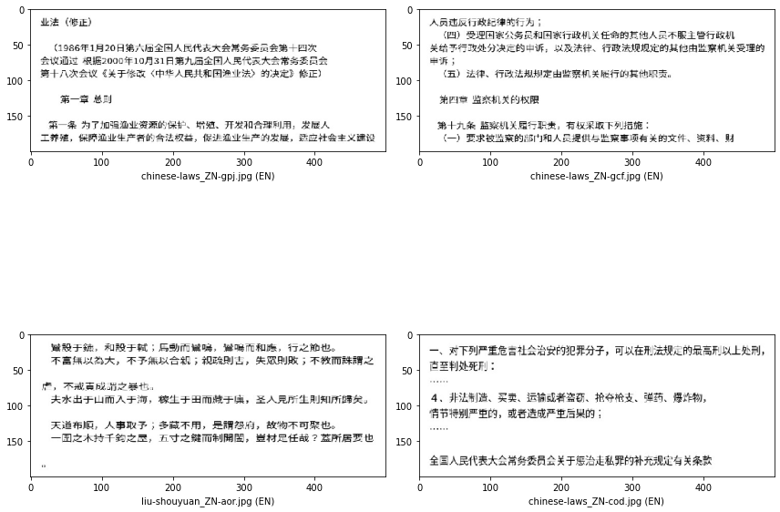

```python
## Print and plot misclassified results
wrongResults = testResults[testResults.predicted != testResults.category]
rows = np.random.choice(wrongResults.index, min(4, wrongResults.shape[0]), replace=False)
print("Example wrong results")
print(wrongResults.sample(min(10, wrongResults.shape[0])))
plt.figure(figsize=(12, 12))
index = 1
for row in rows:
    filename = wrongResults.loc[row, 'filename']
    predicted = wrongResults.loc[row, 'predicted']
    img = load_img(os.path.join(imgDir, "test", filename), target_size=imageSize)
    plt.subplot(2, 2, index)
    plt.imshow(img)
    plt.xlabel(filename + " ({})".format(predicted))
    index += 1
plt.tight_layout()
plt.show()
```

## Summary

Below is a summary of each attempt to distinguish EN/ZN.

Attempt 1

| predicted | EN | ZN |
| --- | --- | --- |
| EN | 2038 | 0 |
| ZN | 4 | 1345 |

`Accuracy 0.9988`

Attempt 2

| predicted | EN | ZN |
| --- | --- | --- |
| EN | 2038 | 0 |
| ZN | 2 | 1347 |

`Accuracy 0.9994`

Attempt 3

| predicted | EN | ZN |
| --- | --- | --- |
| EN | 2038 | 0 |
| ZN | 63 | 1286 |

`Accuracy 0.9814`

Attempt 2 performed the best out of the three if accuracy alone is considered. However, it took about 30 times as long as Attempt 1 to run and only improved its accuracy by two images. If you look at the neural network outlined in Model 1, we can also see that each layer uses a very small number of dimensions. In a realistic world, we can conclude that Attempt 1 produced the best results.

# 3. Crop Images

This model runs the cropped 100x100 images through the same neural network structure as the first model that classified all four languages. `0.4431` is a comparable accuracy when considering the results of this model.

The model used 7,940 parameters and the confusion matrix shows a large improvement. The accuracy is almost doubled from the first attempt to classify all four languages.

| predicted | DA | EN | RU | ZN |
| --- | --- | --- | --- | --- |
| DA | 426 | 573 | 14 | 0 |
| EN | 125 | 1906 | 6 | 1 |
| RU | 229 | 88 | 1383 | 2 |
| ZN | 2 | 6 | 6 | 1335 |

`Accuracy 0.8276`

This block crops images for both the testing and training data, writing the results to `crop_train` and `crop_test` directories. Images are cropped to 100x100 favoring the top-left corner of the image.

```python
from PIL import Image
import os.path, sys

def crop(read_path, write_path, dirs):
  for item in dirs:
    fullpath = os.path.join(read_path,item)
    if os.path.isfile(fullpath):
      im = Image.open(fullpath)
      f, e = os.path.splitext(fullpath)
      imCrop = im.crop((0, 0, 100, 100))
      imCrop.save(write_path + item)

# crop train data
read_path = "../../data/language/train"
write_path = "../../data/language/crop_train/"
dirs = os.listdir(read_path)
crop(read_path, write_path, dirs)

# crop test data
read_path = "../../data/language/test"
write_path = "../../data/language/crop_test/"
dirs = os.listdir(read_path)
crop(read_path, write_path, dirs)
```

```python
## Define image properties:
imgDir = "../../data/language"
targetWidth, targetHeight = 100, 100
imageSize = (targetWidth, targetHeight)
channels = 1  # color channels
```

```python
## define other constants, including command line argument defaults
batch_size = 16
epochs = 2
```

```python
## Prepare dataset for training model:
original_filenames = os.listdir(os.path.join(imgDir, "crop_train"))

filenames = []
categories = []

for x in original_filenames:
  language = x.split("_")[1:][0]
  filenames.append(x)
  categories.append(language[:2])

print(len(filenames), "images found")
df = pd.DataFrame({
    'filename':filenames,
    'category':pd.Series(categories)
})

print("data files:")
print(df.sample(5))
nCategories = df.category.nunique()
print("categories:\n", df.category.value_counts())
## Create model
from tensorflow.keras.models import Sequential
from tensorflow.keras.layers import Conv2D,\
    MaxPooling2D, AveragePooling2D,\
    Dropout,Flatten,Dense,Activation,\
    BatchNormalization
```

```
24410 images found
data files:
                                filename category
4696                evolution_EN-brm.jpg       EN
16831            ocean-tramps_EN-aie.jpg       EN
15470            chinese-laws_ZN-dcs.jpg       ZN
4812   derzhavin-duhovnye-ody_RU-alz.jpg       RU
5888                  dracula_EN-dwl.jpg       EN
categories:
 EN    8454
RU    6502
ZN    5353
DA    4101
Name: category, dtype: int64
```

```python
# sequential (not recursive) model (one input, one output)
model=Sequential()

model.add(Conv2D(16,
                 kernel_size=3,
                 strides=2,
                 activation='relu',
                 input_shape=(targetWidth, targetHeight, channels)))
model.add(BatchNormalization())
model.add(MaxPooling2D(pool_size=3))
model.add(Dropout(0.25))

model.add(Conv2D(8,
                 kernel_size=3,
                 activation='relu'))
model.add(BatchNormalization())
model.add(MaxPooling2D(pool_size=(2, 2)))
model.add(Dropout(0.25))

model.add(Flatten())
model.add(Dense(16, activation='relu'))
model.add(BatchNormalization())
model.add(Dropout(0.5))
model.add(Dense(8, activation='softmax'))

model.add(Dense(nCategories, activation='softmax'))

model.compile(loss='categorical_crossentropy',
              metrics=['accuracy'])
model.summary()
```

```
Model: "sequential_7"
_________________________________________________________________
 Layer (type)                Output Shape              Param #
=================================================================
 conv2d_14 (Conv2D)          (None, 49, 49, 16)        160

 batch_normalization_21 (Bat  (None, 49, 49, 16)       64
 chNormalization)

 max_pooling2d_14 (MaxPoolin  (None, 16, 16, 16)       0
 g2D)

 dropout_21 (Dropout)        (None, 16, 16, 16)        0

 conv2d_15 (Conv2D)          (None, 14, 14, 8)         1160

 batch_normalization_22 (Bat  (None, 14, 14, 8)        32
 chNormalization)

 max_pooling2d_15 (MaxPoolin  (None, 7, 7, 8)          0
 g2D)

 dropout_22 (Dropout)        (None, 7, 7, 8)           0

 flatten_7 (Flatten)         (None, 392)               0

 dense_21 (Dense)            (None, 16)                6288

 batch_normalization_23 (Bat  (None, 16)               64
 chNormalization)

 dropout_23 (Dropout)        (None, 16)                0

 dense_22 (Dense)            (None, 8)                 136

 dense_23 (Dense)            (None, 4)                 36

=================================================================
Total params: 7,940
Trainable params: 7,860
Non-trainable params: 80
_________________________________________________________________
```

```python
## Training and validation data generator:
train_generator = ImageDataGenerator(rescale=1./255).\
    flow_from_dataframe(df,
                        os.path.join(imgDir, "crop_train"),
                        x_col='filename', y_col='category',
                        target_size=imageSize,
                        class_mode='categorical',
                        color_mode="grayscale",
                        batch_size=batch_size,
                        shuffle=True)
label_map = train_generator.class_indices
## Model Training:
history = model.fit(
    train_generator,
    epochs=epochs
)
```

```
Found 24410 validated image filenames belonging to 4 classes.
```

```python
## Test data preparation:
testDir = os.path.join(imgDir, "crop_test")
fNames = os.listdir(testDir)

filenames = []
categories = []

for x in fNames:
  language = x.split("_")[1:][0]
  filenames.append(x)
  categories.append(language[:2])


print(len(filenames), "test images")
testResults = pd.DataFrame({
    'filename': filenames,
    'category': pd.Series(categories)
})
nb_samples = testResults.shape[0]
print(nb_samples, "test files read from", testDir)
test_generator = ImageDataGenerator(rescale=1./255).\
    flow_from_dataframe(testResults,
                        os.path.join(imgDir, "crop_test"),
                        x_col='filename',
                        class_mode = None,
                        target_size = imageSize,
                        batch_size=batch_size,
                        shuffle = False,
                        # do _not_ randomize the order!
                        # this would clash with the file name order!
                        color_mode="grayscale"
    )
```

```
6102 test images
6102 test files read from ../../data/language/crop_test
Found 6102 validated image filenames.
```

```python
## Make categorical prediction:
print("predicting")
phat = model.predict(test_generator)
print("Predicted array shape:", phat.shape)
print("Example:\n", phat[:5])
```

```
predicting
Predicted array shape: (6102, 4)
Example:
 [[0.01095447 0.0105448  0.01237634 0.9661244 ]
 [0.5188792  0.33189178 0.12481921 0.02440984]
 [0.0109565  0.01054675 0.01237722 0.9661195 ]
 [0.01095717 0.01054737 0.01237764 0.96611786]
 [0.20704843 0.729097   0.0574287  0.00642592]]
```

```python
## Convert labels to categories:
testResults['predicted'] = pd.Series(np.argmax(phat, axis=-1), index=testResults.index)
print(testResults.head())
labelMap = {v: k for k, v in label_map.items()}
testResults["predicted"] = testResults.predicted.replace(labelMap)
print("confusion matrix")
print(pd.crosstab(testResults.category, testResults.predicted))
print("Accuracy", np.mean(testResults.category == testResults.predicted))
```

```
                            filename category  predicted
0            chinese-laws_ZN-frt.jpg       ZN          3
1  derzhavin-duhovnye-ody_RU-aty.jpg       RU          0
2            chinese-laws_ZN-djp.jpg       ZN          3
3            chinese-laws_ZN-avm.jpg       ZN          3
4                 dracula_EN-doy.jpg       EN          1
confusion matrix
predicted   DA    EN    RU    ZN
category
DA         426   573    14     0
EN         125  1906     6     1
RU         229    88  1383     2
ZN           2     6     6  1335
Accuracy 0.8275975090134382
```

```
Example wrong results
                                 filename category predicted
1991     rachinskij-1001-tasks_RU-asi.jpg       RU        EN
4773         magnussen-thisted_DA-aht.jpg       DA        EN
3280  aakjaer-samlede-verker-3_DA-bls.jpg       DA        EN
5705  aakjaer-samlede-verker-3_DA-abj.jpg       DA        EN
907   aakjaer-samlede-verker-1_DA-aqc.jpg       DA        EN
35          claudes-confession_EN-aah.jpg       EN        DA
2810  aakjaer-samlede-verker-2_DA-atv.jpg       DA        EN
3712  aakjaer-samlede-verker-3_DA-agu.jpg       DA        RU
989          magnussen-thisted_DA-ahl.jpg       DA        EN
1218    derzhavin-duhovnye-ody_RU-aaj.jpg       RU        DA
```

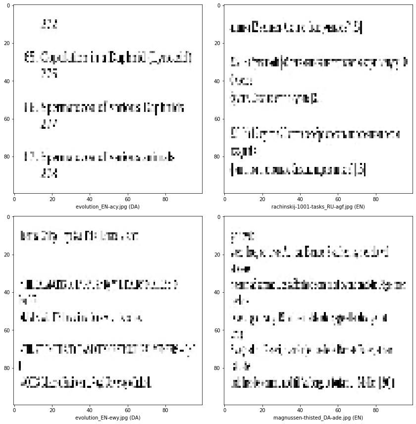

```python
## Print and plot misclassified results
wrongResults = testResults[testResults.predicted != testResults.category]
rows = np.random.choice(wrongResults.index, min(4, wrongResults.shape[0]), replace=False)
print("Example wrong results")
print(wrongResults.sample(min(10, wrongResults.shape[0])))
plt.figure(figsize=(12, 12))
index = 1
for row in rows:
    filename = wrongResults.loc[row, 'filename']
    predicted = wrongResults.loc[row, 'predicted']
    img = load_img(os.path.join(imgDir, "test", filename), target_size=imageSize)
    plt.subplot(2, 2, index)
    plt.imshow(img)
    plt.xlabel(filename + " ({})".format(predicted))
    index += 1
plt.tight_layout()
plt.show()
```

# 4. Other Languages

## EN, ZN, RU

This model adds in RU to the existing EN and ZN model. An issue that occurred during testing is that the second to last dense layer used 2 dimensions. This means that when the model had built a knowledge of three languages, it was forced to combine two languages into one channel. This was addressed by restoring the dense layer to have 8 dimensions (at least more than 3) and the model saw an improvement.

The confusion matrix performs extremely well with `78,459` parameters and 2 epochs. The most common issue with this model is that some RU images were classified as EN by the model.

| predicted | EN | RU | ZN |
| --- | --- | --- | --- |
| EN | 2035 | 3 | 0 |
| RU | 87 | 1615 | 0 |
| ZN | 4 | 0 | 1345 |

`Accuracy 0.9815`

```python
## Define image properties:
imgDir = "../../data/language"
targetWidth, targetHeight = 200, 500
imageSize = (targetWidth, targetHeight)
channels = 1  # color channels
```

```python
## define other constants, including command line argument defaults
batch_size = 16
epochs = 2
```

```python
## Prepare dataset for training model:
original_filenames = os.listdir(os.path.join(imgDir, "train"))

filenames = []
categories = []

for x in original_filenames:
  language = x.split("_")[1:][0]
  if "EN-" in language or "ZN-" in language or "RU-" in language:
    filenames.append(x)
    categories.append(language[:2])

print(len(filenames), "images found")
df = pd.DataFrame({
    'filename':filenames,
    'category':pd.Series(categories)
})

print("data files:")
print(df.sample(5))
nCategories = df.category.nunique()
print("categories:\n", df.category.value_counts())
## Create model
from tensorflow.keras.models import Sequential
from tensorflow.keras.layers import Conv2D,\
    MaxPooling2D, AveragePooling2D,\
    Dropout,Flatten,Dense,Activation,\
    BatchNormalization
```

```
20309 images found
data files:
                               filename category
17993  tolstoy-voina-i-mir-2_RU-bsz.jpg       RU
8537               evolution_EN-cdv.jpg       EN
604    rachinskij-1001-tasks_RU-abw.jpg       RU
5268            chinese-laws_ZN-fmu.jpg       ZN
16288  tolstoy-voina-i-mir-3_RU-dlb.jpg       RU
categories:
 EN    8454
RU    6502
ZN    5353
Name: category, dtype: int64
```

```python
# sequential (not recursive) model (one input, one output)
model=Sequential()

model.add(Conv2D(16,
                 kernel_size=3,
                 strides=2,
                 activation='relu',
                 input_shape=(targetWidth, targetHeight, channels)))
model.add(BatchNormalization())
model.add(MaxPooling2D(pool_size=3))
model.add(Dropout(0.25))

model.add(Conv2D(8,
                 kernel_size=3,
                 activation='relu'))
model.add(BatchNormalization())
model.add(MaxPooling2D(pool_size=(2, 2)))
model.add(Dropout(0.25))

model.add(Flatten())
model.add(Dense(16, activation='relu'))
model.add(BatchNormalization())
model.add(Dropout(0.5))
model.add(Dense(8, activation='softmax'))

model.add(Dense(nCategories, activation='softmax'))

model.compile(loss='categorical_crossentropy',
              metrics=['accuracy'])
model.summary()
```

```
Model: "sequential_2"
_________________________________________________________________
 Layer (type)                Output Shape              Param #
=================================================================
 conv2d_4 (Conv2D)           (None, 99, 249, 16)       160

 batch_normalization_6 (Batc  (None, 99, 249, 16)      64
 hNormalization)

 max_pooling2d_4 (MaxPooling  (None, 33, 83, 16)       0
 2D)

 dropout_6 (Dropout)         (None, 33, 83, 16)        0

 conv2d_5 (Conv2D)           (None, 31, 81, 8)         1160

 batch_normalization_7 (Batc  (None, 31, 81, 8)        32
 hNormalization)

 max_pooling2d_5 (MaxPooling  (None, 15, 40, 8)        0
 2D)

 dropout_7 (Dropout)         (None, 15, 40, 8)         0

 flatten_2 (Flatten)         (None, 4800)              0

 dense_6 (Dense)             (None, 16)                76816

 batch_normalization_8 (Batc  (None, 16)               64
 hNormalization)

 dropout_8 (Dropout)         (None, 16)                0

 dense_7 (Dense)             (None, 8)                 136

 dense_8 (Dense)             (None, 3)                 27

=================================================================
Total params: 78,459
Trainable params: 78,379
Non-trainable params: 80
_________________________________________________________________
```

```python
## Training and validation data generator:
train_generator = ImageDataGenerator(rescale=1./255).\
    flow_from_dataframe(df,
                        os.path.join(imgDir, "train"),
                        x_col='filename', y_col='category',
                        target_size=imageSize,
                        class_mode='categorical',
                        color_mode="grayscale",
                        batch_size=batch_size,
                        shuffle=True)
label_map = train_generator.class_indices
## Model Training:
history = model.fit(
    train_generator,
    epochs=epochs
)
```

```
Found 20309 validated image filenames belonging to 3 classes.
```

```python
## Test data preparation:
testDir = os.path.join(imgDir, "test")
fNames = os.listdir(testDir)

filenames = []
categories = []

for x in fNames:
  language = x.split("_")[1:][0]
  if "EN-" in language or "ZN-" in language or "RU-" in language:
    filenames.append(x)
    categories.append(language[:2])


print(len(filenames), "test images")
testResults = pd.DataFrame({
    'filename': filenames,
    'category': pd.Series(categories)
})
nb_samples = testResults.shape[0]
print(nb_samples, "test files read from", testDir)
test_generator = ImageDataGenerator(rescale=1./255).\
    flow_from_dataframe(testResults,
                        os.path.join(imgDir, "test"),
                        x_col='filename',
                        class_mode = None,
                        target_size = imageSize,
                        batch_size=batch_size,
                        shuffle = False,
                        # do _not_ randomize the order!
                        # this would clash with the file name order!
                        color_mode="grayscale"
    )
```

```
5089 test images
5089 test files read from ../../data/language/test
Found 5089 validated image filenames.
```

```python
## Make categorical prediction:
print("predicting")
phat = model.predict(test_generator)
print("Predicted array shape:", phat.shape)
print("Example:\n", phat[:5])
```

```
predicting
Predicted array shape: (5089, 3)
Example:
 [[0.00999539 0.01402463 0.9759799 ]
 [0.26732454 0.7106226  0.02205288]
 [0.0099953  0.01402451 0.97598016]
 [0.00999544 0.01402471 0.9759798 ]
 [0.9715422  0.02056612 0.00789172]]
```

```python
## Convert labels to categories:
testResults['predicted'] = pd.Series(np.argmax(phat, axis=-1), index=testResults.index)
print(testResults.head())
labelMap = {v: k for k, v in label_map.items()}
testResults["predicted"] = testResults.predicted.replace(labelMap)
print("confusion matrix")
print(pd.crosstab(testResults.category, testResults.predicted))
print("Accuracy", np.mean(testResults.category == testResults.predicted))
```

```
                            filename category  predicted
0            chinese-laws_ZN-frt.jpg       ZN          2
1  derzhavin-duhovnye-ody_RU-aty.jpg       RU          1
2            chinese-laws_ZN-djp.jpg       ZN          2
3            chinese-laws_ZN-avm.jpg       ZN          2
4                 dracula_EN-doy.jpg       EN          0
confusion matrix
predicted    EN    RU    ZN
category
EN         2035     3     0
RU           87  1615     0
ZN            4     0  1345
Accuracy 0.9815287875810572
```

```
Example wrong results
                               filename category predicted
402   derzhavin-duhovnye-ody_RU-abw.jpg       RU        EN
3432   tolstoy-voina-i-mir-3_RU-dik.jpg       RU        EN
3348   tolstoy-voina-i-mir-1_RU-adj.jpg       RU        EN
3482   tolstoy-voina-i-mir-3_RU-aox.jpg       RU        EN
980   derzhavin-duhovnye-ody_RU-atk.jpg       RU        EN
4373   tolstoy-voina-i-mir-1_RU-axu.jpg       RU        EN
2381   tolstoy-voina-i-mir-1_RU-cry.jpg       RU        EN
2867  derzhavin-duhovnye-ody_RU-aqk.jpg       RU        EN
4879   tolstoy-voina-i-mir-1_RU-awj.jpg       RU        EN
2991   tolstoy-voina-i-mir-2_RU-dbd.jpg       RU        EN
```

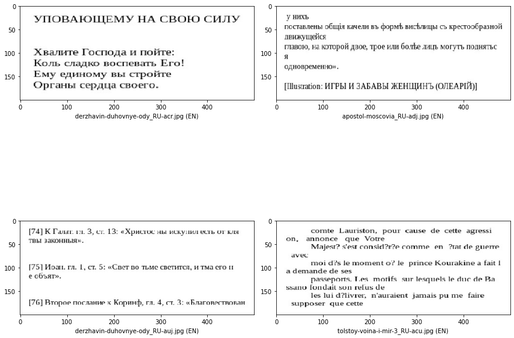

```python
## Print and plot misclassified results
wrongResults = testResults[testResults.predicted != testResults.category]
rows = np.random.choice(wrongResults.index, min(4, wrongResults.shape[0]), replace=False)
print("Example wrong results")
print(wrongResults.sample(min(10, wrongResults.shape[0])))
plt.figure(figsize=(12, 12))
index = 1
for row in rows:
    filename = wrongResults.loc[row, 'filename']
    predicted = wrongResults.loc[row, 'predicted']
    img = load_img(os.path.join(imgDir, "test", filename), target_size=imageSize)
    plt.subplot(2, 2, index)
    plt.imshow(img)
    plt.xlabel(filename + " ({})".format(predicted))
    index += 1
plt.tight_layout()
plt.show()
```

## EN, ZN, RU, DA

The final model includes all languages: EN, ZN, RU, and DA. It uses `78,468` parameters. DA and EN characters look very similar - this is likely to be an issue with image classification.

From the confusion matrix, we can immediately tell that this model did excellent work identifying ZN images. As expected, the most common issue this model had was distinguishing DA and EN. It predicted about 7 times DA images as EN than it did EN images as DA.

| predicted | DA | EN | RU | ZN |
| --- | --- | --- | --- | --- |
| DA | 609 | 385 | 19 | 0 |
| EN | 51 | 1969 | 18 | 0 |
| RU | 119 | 16 | 1567 | 0 |
| ZN | 12 | 0 | 1 | 1336 |

`Accuracy 0.8982`

```python
## Define image properties:
imgDir = "../../data/language"
targetWidth, targetHeight = 200, 500
imageSize = (targetWidth, targetHeight)
channels = 1  # color channels
```

```python
## define other constants, including command line argument defaults
batch_size = 16
epochs = 2
```

```python
## Prepare dataset for training model:
original_filenames = os.listdir(os.path.join(imgDir, "train"))

filenames = []
categories = []

for x in original_filenames:
  language = x.split("_")[1:][0]
  filenames.append(x)
  categories.append(language[:2])

print(len(filenames), "images found")
df = pd.DataFrame({
    'filename':filenames,
    'category':pd.Series(categories)
})

print("data files:")
print(df.sample(5))
nCategories = df.category.nunique()
print("categories:\n", df.category.value_counts())
## Create model
from tensorflow.keras.models import Sequential
from tensorflow.keras.layers import Conv2D,\
    MaxPooling2D, AveragePooling2D,\
    Dropout,Flatten,Dense,Activation,\
    BatchNormalization
```

```
24410 images found
data files:
                                  filename category
4760   aakjaer-samlede-verker-3_DA-atn.jpg       DA
604    aakjaer-samlede-verker-2_DA-aqk.jpg       DA
2085                  evolution_EN-awr.jpg       EN
19022                   journey_EN-avn.jpg       EN
10655  aakjaer-samlede-verker-3_DA-cqv.jpg       DA
categories:
 EN    8454
RU    6502
ZN    5353
DA    4101
Name: category, dtype: int64
```

```python
# sequential (not recursive) model (one input, one output)
model=Sequential()

model.add(Conv2D(16,
                 kernel_size=3,
                 strides=2,
                 activation='relu',
                 input_shape=(targetWidth, targetHeight, channels)))
model.add(BatchNormalization())
model.add(MaxPooling2D(pool_size=3))
model.add(Dropout(0.25))

model.add(Conv2D(8,
                 kernel_size=3,
                 activation='relu'))
model.add(BatchNormalization())
model.add(MaxPooling2D(pool_size=(2, 2)))
model.add(Dropout(0.25))

model.add(Flatten())
model.add(Dense(16, activation='relu'))
model.add(BatchNormalization())
model.add(Dropout(0.5))
model.add(Dense(8, activation='softmax'))

model.add(Dense(nCategories, activation='softmax'))

model.compile(loss='categorical_crossentropy',
              metrics=['accuracy'])
model.summary()
```

```
Model: "sequential_4"
_________________________________________________________________
 Layer (type)                Output Shape              Param #
=================================================================
 conv2d_8 (Conv2D)           (None, 99, 249, 16)       160

 batch_normalization_12 (Bat  (None, 99, 249, 16)      64
 chNormalization)

 max_pooling2d_8 (MaxPooling  (None, 33, 83, 16)       0
 2D)

 dropout_12 (Dropout)        (None, 33, 83, 16)        0

 conv2d_9 (Conv2D)           (None, 31, 81, 8)         1160

 batch_normalization_13 (Bat  (None, 31, 81, 8)        32
 chNormalization)

 max_pooling2d_9 (MaxPooling  (None, 15, 40, 8)        0
 2D)

 dropout_13 (Dropout)        (None, 15, 40, 8)         0

 flatten_4 (Flatten)         (None, 4800)              0

 dense_12 (Dense)            (None, 16)                76816

 batch_normalization_14 (Bat  (None, 16)               64
 chNormalization)

 dropout_14 (Dropout)        (None, 16)                0

 dense_13 (Dense)            (None, 8)                 136

 dense_14 (Dense)            (None, 4)                 36

=================================================================
Total params: 78,468
Trainable params: 78,388
Non-trainable params: 80
_________________________________________________________________
```

```python
## Training and validation data generator:
train_generator = ImageDataGenerator(rescale=1./255).\
    flow_from_dataframe(df,
                        os.path.join(imgDir, "train"),
                        x_col='filename', y_col='category',
                        target_size=imageSize,
                        class_mode='categorical',
                        color_mode="grayscale",
                        batch_size=batch_size,
                        shuffle=True)
label_map = train_generator.class_indices
## Model Training:
history = model.fit(
    train_generator,
    epochs=epochs
)
```

```
Found 24410 validated image filenames belonging to 4 classes.
```

```python
## Test data preparation:
testDir = os.path.join(imgDir, "test")
fNames = os.listdir(testDir)

filenames = []
categories = []

for x in fNames:
  language = x.split("_")[1:][0]
  filenames.append(x)
  categories.append(language[:2])


print(len(filenames), "test images")
testResults = pd.DataFrame({
    'filename': filenames,
    'category': pd.Series(categories)
})
nb_samples = testResults.shape[0]
print(nb_samples, "test files read from", testDir)
test_generator = ImageDataGenerator(rescale=1./255).\
    flow_from_dataframe(testResults,
                        os.path.join(imgDir, "test"),
                        x_col='filename',
                        class_mode = None,
                        target_size = imageSize,
                        batch_size=batch_size,
                        shuffle = False,
                        # do _not_ randomize the order!
                        # this would clash with the file name order!
                        color_mode="grayscale"
    )
```

```
6102 test images
6102 test files read from ../../data/language/test
Found 6102 validated image filenames.
```

```python
## Make categorical prediction:
print("predicting")
phat = model.predict(test_generator)
print("Predicted array shape:", phat.shape)
print("Example:\n", phat[:5])
```

```
predicting
Predicted array shape: (6102, 4)
Example:
 [[0.0087236  0.00957763 0.00915427 0.97254455]
 [0.01380287 0.01697094 0.9645252  0.00470098]
 [0.008716   0.00957051 0.00914796 0.97256553]
 [0.0087171  0.00957112 0.00914832 0.9725635 ]
 [0.0617812  0.91538614 0.01785555 0.00497707]]
```

```python
## Convert labels to categories:
testResults['predicted'] = pd.Series(np.argmax(phat, axis=-1), index=testResults.index)
print(testResults.head())
labelMap = {v: k for k, v in label_map.items()}
testResults["predicted"] = testResults.predicted.replace(labelMap)
print("confusion matrix")
print(pd.crosstab(testResults.category, testResults.predicted))
print("Accuracy", np.mean(testResults.category == testResults.predicted))
```

```
                            filename category  predicted
0            chinese-laws_ZN-frt.jpg       ZN          3
1  derzhavin-duhovnye-ody_RU-aty.jpg       RU          2
2            chinese-laws_ZN-djp.jpg       ZN          3
3            chinese-laws_ZN-avm.jpg       ZN          3
4                 dracula_EN-doy.jpg       EN          1
confusion matrix
predicted   DA    EN    RU    ZN
category
DA         609   385    19     0
EN          51  1969    18     0
RU         119    16  1567     0
ZN          12     0     1  1336
Accuracy 0.8982300884955752
```

```
Example wrong results
                                 filename category predicted
4751  aakjaer-samlede-verker-3_DA-bsr.jpg       DA        EN
2327    derzhavin-duhovnye-ody_RU-afy.jpg       RU        DA
3403    derzhavin-duhovnye-ody_RU-ast.jpg       RU        DA
3641  aakjaer-samlede-verker-3_DA-bno.jpg       DA        EN
2331                 evolution_EN-daj.jpg       EN        DA
2735  aakjaer-samlede-verker-3_DA-cgn.jpg       DA        EN
1167                 evolution_EN-ewp.jpg       EN        RU
6005    derzhavin-duhovnye-ody_RU-aby.jpg       RU        DA
4753         magnussen-thisted_DA-aig.jpg       DA        EN
757   aakjaer-samlede-verker-1_DA-bzb.jpg       DA        EN
```

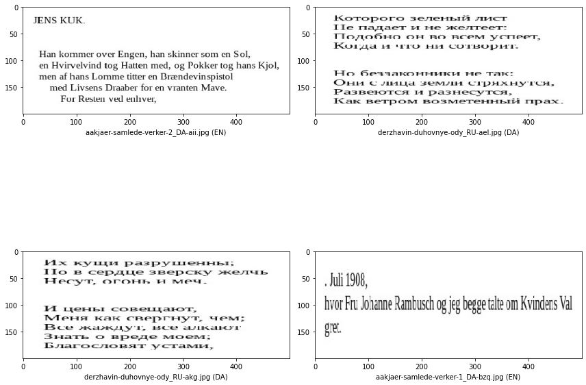

```python
## Print and plot misclassified results
wrongResults = testResults[testResults.predicted != testResults.category]
rows = np.random.choice(wrongResults.index, min(4, wrongResults.shape[0]), replace=False)
print("Example wrong results")
print(wrongResults.sample(min(10, wrongResults.shape[0])))
plt.figure(figsize=(12, 12))
index = 1
for row in rows:
    filename = wrongResults.loc[row, 'filename']
    predicted = wrongResults.loc[row, 'predicted']
    img = load_img(os.path.join(imgDir, "test", filename), target_size=imageSize)
    plt.subplot(2, 2, index)
    plt.imshow(img)
    plt.xlabel(filename + " ({})".format(predicted))
    index += 1
plt.tight_layout()
plt.show()
```